# task19

Juste

2016 m lapkritis 28 d

Įkeliami duomenys.

```r
train <- read.csv("train.csv")
head(train)
```

```
##      X        y          x status
## 1 1284 7.181676  1.7742700     II
## 2  565 2.038279 -0.5132191    UAB
## 3 1409 4.584284  0.2377189     II
## 4  641 4.944990  1.3973637    UAB
## 5  274 6.498639  2.4599820    UAB
## 6 1849 6.142526  1.0636347     II
```

Iš pradžių apsibrėžiu kintamuosius ir pažiūriu , kaip atrodo pateikti duomenys grafike.

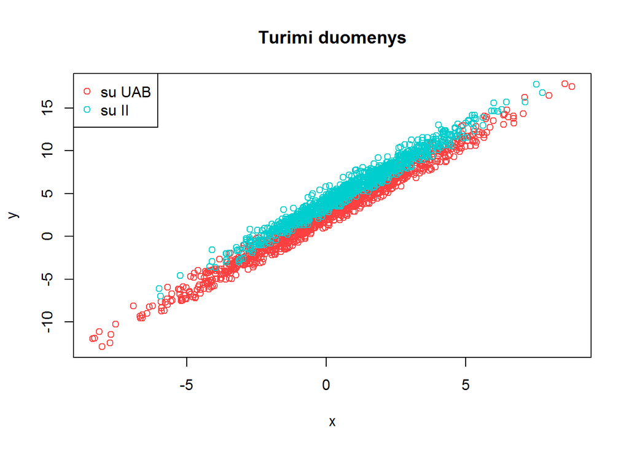

```r
x<-train$x
y<-train$y
status<-train$status
plot(x[status=="UAB"],y[status=="UAB"], col="brown1", xlab="x", ylab="y", main = "Turimi duomenys")
points(x[status=="II"], y[status=="II"], col="cyan3")
legend ("topleft" , legend=c("su UAB", "su II"), col=c("brown1","cyan3"), pch=c(1,1))
```

Kadangi status kintamieji bus fiktyvūs , turime jiems priskirti reikšmes. Tegu , kai Status = UAB, reikšmė bus 1, o kai status=II, reikšmė bus 0.

```r
k=1
k[status=='II'] = 0
k =(status=='UAB')*1
```

Mūsų regresijs lygtis turėtų būti tokia:

y=bx+l1k+l2(1-k)

l1, l2 - alfa1, alfa2, atitinkamai

Todėl reik apsibrėžti trečią kintamąjį.

```r
z=1-k
```

1. Užduoties dalis

Mūsų modelis:

```r
mod<-lm(y~x+k+z-1)
```

Gautos prognozės:

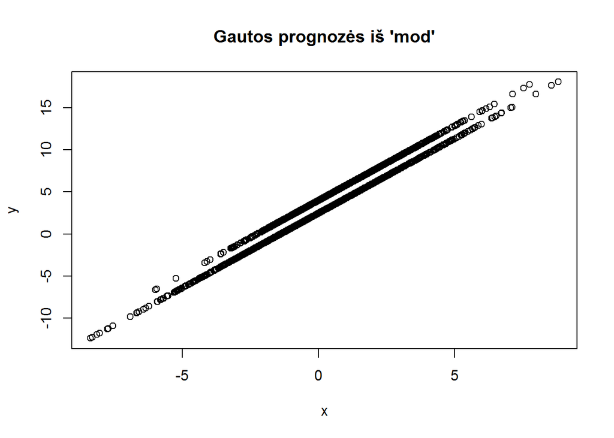

```r
ypredicted<-predict(mod, data.frame(x))
plot(x,ypredicted, xlab="x", ylab="y", main="Gautos prognozės iš 'mod'")
```

2. Užduoties dalis

Kai vertinama nuo status tiesiogiai, nepriskiriant reiksmių ir paliekant tai R-ui

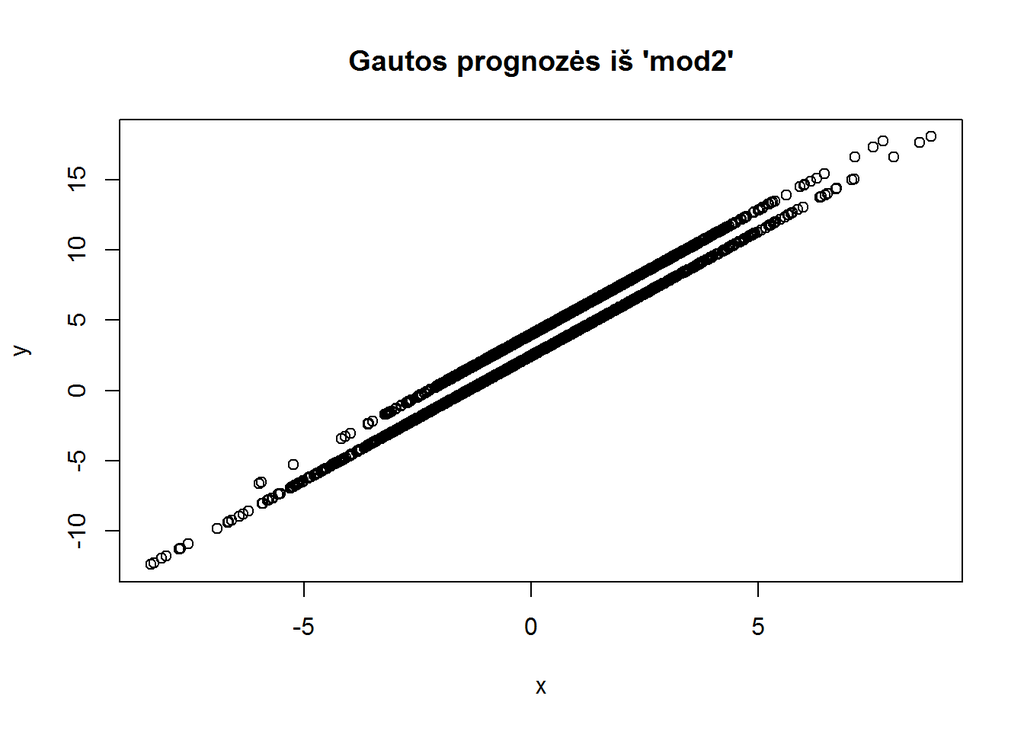

```r
mod2<-lm(y~x+status)
y2predicted<-predict(mod2,data.frame=(x))
plot(x,y2predicted, xlab="x", ylab="y", main="Gautos prognozės iš 'mod2'")
```

3. Palyginkite dviejų vertinimų rezultatus: R-kvadratą, F statistiką ir paklaidų dispersiją.

```r
#summary(mod)
#summary(mod2)
```

Mod: Paklaidu dispersija (sd error) 0.6797

R kvadratas 0.9881

F statistika 5.513e+04 on 3

Mod2: Pakl disp (sd error) 0.6797

R kvadratas 0.979

F statistika 4.653e+04 on 2

Paklaidų standartinis nuokrypis yra vidutinis dydis, kuriuo mūsų priklausomas kintamasis skirsis nuo tikrosios regresijos tiesės. Abiejų modelių standartinis nuokrypis vienodas.

Multiple R-squared Tai matas, skirtas įvertinti modelio tinkamumą stebėjimams.(kaip arti duomenims yra regresijos tiesė) . Kuo didesnis skaičius - tuo modelis geresnis. Vienetas atitinka tobulą modelį, o mažiausia reikšmė - 0.

R-squared = Explained variation / Total variation

Mod R-squared reikšmė didesnė nei Mod2. Mod paaiškina daugiau modelio suprognozuotų reikšmių, nei mod2.

F-statistic Indikatorius , nusakantis ryšį tarp priklausomo ir nepriklausomo kintamujų. Kuo toliau F-statistic yra nuo 1 , tuo geriau.

F= explained variation (k-1) / unexplained variation (n-k)

Mod F-statistic yra 55130, o Mod2 46530, taigi Mod reikšmė yra toliau nuo 1, negu Mod2.

3. Palyginkite modelių prognozes.

```r
sd(ypredicted-y2predicted)
```

```
## [1] 4.492307e-15
```

```r
summary(ypredicted-y2predicted)
```

```
##       Min.    1st Qu.     Median       Mean    3rd Qu.       Max.
## -2.132e-14 -1.288e-14 -8.882e-15 -9.462e-15 -5.329e-15  1.776e-15
```

Min ir Max skirtumų reikšmės mažos, todėl standartinis nuokrypis mažas. Santraukoje matome, kad skirtumų vidurkis taip pat labai mažas, todėl galima sakyti, kad modelių prognozės nesiskiria.

4. Duomenys “test” , jų pasiskirstymas.

```r
test<-read.csv("test.csv")
head(test)
```

```
##      X         y           x status
## 1 1922 -5.226414 -4.30187942     II
## 2  460 -3.434574 -3.01428086    UAB
## 3 1541  3.723301  0.09661132     II
## 4 1848  5.367149  0.76098320     II
## 5  913  1.681663 -0.70828767    UAB
## 6  703 -4.972179 -3.76804326    UAB
```

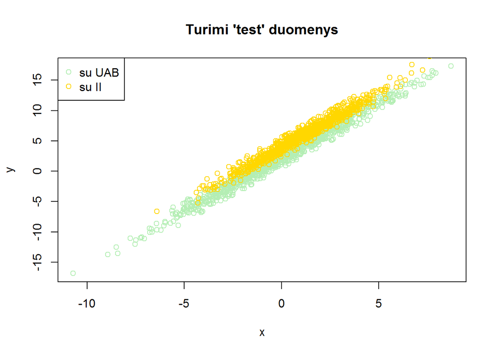

```r
xt<-test$x
yt<-test$y
statust<-test$status
plot(xt[statust=="UAB"],yt[statust=="UAB"], col="darkseagreen2", xlab="x", ylab="y", main = "Turimi 'test' duomenys")
points(xt[statust=="II"], yt[statust=="II"], col="gold")
legend ("topleft" , legend=c("su UAB", "su II"), col=c("darkseagreen2","gold"), pch=c(1,1))
```

Test duomenų modelis.

```r
kt=1
kt[statust=='II'] = 0
kt =(statust=='UAB')*1
zt=1-kt
modt<-lm(yt~xt+kt+zt-1)
ytpredicted<-predict(modt, data.frame(xt))
```

Test duomenų prognozės vaizdas:

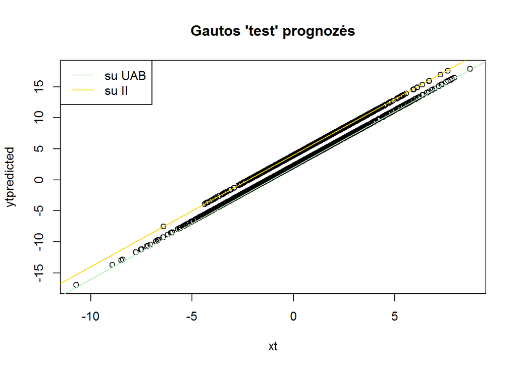

```r
plot(xt,ytpredicted, main="Gautos 'test' prognozės")
abline(2,1.8, col="darkseagreen2")
abline(4,1.8, col="gold")
legend ("topleft" , legend=c("su UAB", "su II"), col=c("darkseagreen2","gold"), lty=c(1,1))
```

Bendras vaizdas:

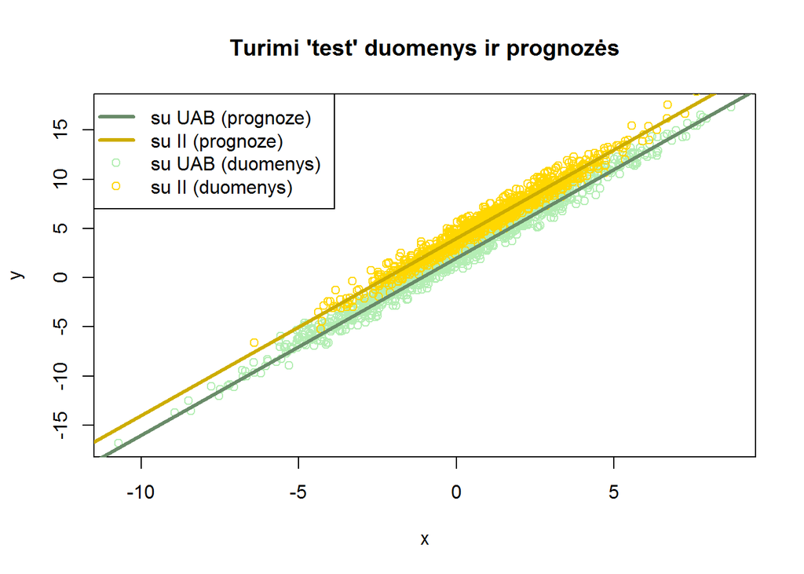

```r
plot(xt[statust=="UAB"],yt[statust=="UAB"], col="darkseagreen2", xlab="x", ylab="y", main = "Turimi 'test' duomenys ir prognozės")
points(xt[statust=="II"], yt[statust=="II"], col="gold")
abline(2,1.8, col="darkseagreen4", lwd=3)
abline(4,1.8, col="gold3", lwd=3)
legend ("topleft" , legend=c("su UAB (prognoze) ", "su II (prognoze)","su UAB (duomenys) ", "su II (duomenys)"), col=c("darkseagreen4","gold3","darkseagreen2","gold"), lwd=c(3,3, NA , NA), pch=c(NA, NA, 1,1))
```